# Inquinamento dell’aria a Pechino

Roberto Senatore

8 giugno 2021

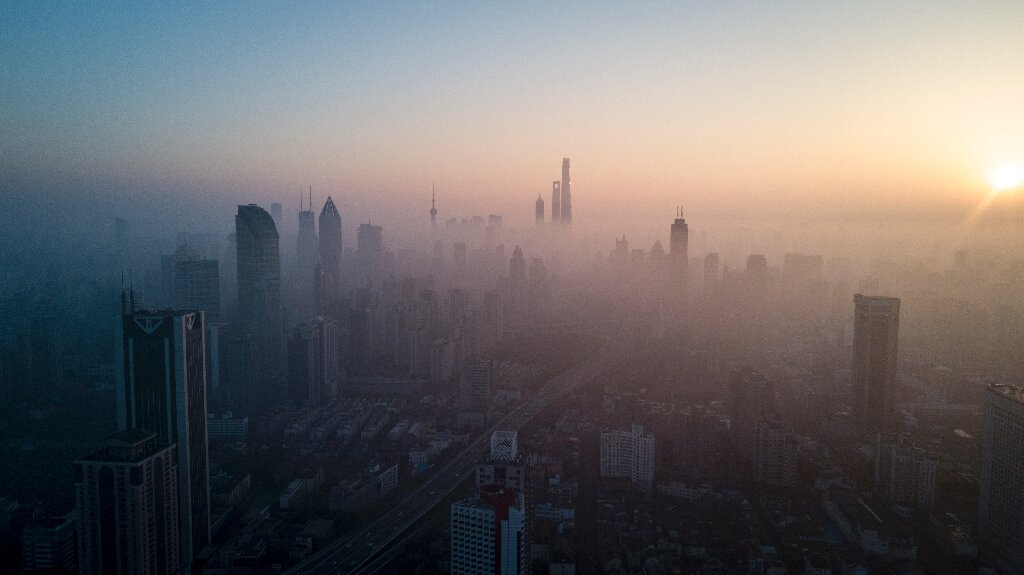

## Introduzione

L’inquinamento atmosferico è uno dei grandi problemi del 21° secolo, lo sviluppo urbano attorno alle grandi capitali del mondo ha reso l’aria di queste città sempre meno respirabile e dannosa per la salute dell’uomo.  
La principale causa di inquinamento è imputabile alla presenza delle **polveri sottili**, nome per riferirsi all’insieme di particelle presenti nell’atmosfera indicate spesso con il nome di **particolato**, che possono contenere: solfato, nitrati, cloruro di sodio, carbonio nero, ect.  
L’origine può essere associata ad attività naturali come incendi boschivi ed eruzioni vulcaniche e all’attività umana, in particolare industrie, riscaldamenti domestici e l’usura dei freni e dei pneumatici.  
L’Organizzazione mondiale della Sanità (OMS) l’ha classificato come [cancerogeno](https://web.archive.org/web/20160529064001/http://ehp.niehs.nih.gov/1408092/), e in base alla sua dimensione, che può essere minore di 10 micron (**PM10**) o di 2.5 micron (**PM2.5**), può penetrare nei bronchi e perfino negli alveoli polmonari provocando l’insorgenza di malattie polmonari e cardiovascolari.  
I valori annuali limite di esposizione secondo l’OMS sono di 25 µg/m³ per il PM2.5 e 40 µg/m³ per il PM10. A Pechino il 23 gennaio del 2012 il valore massimo registrato è stato di 994 µg/m³.

## Dati

La presenza del particolato ha reso alcune città del continente asiatico tra le più inquinate del mondo, ragion per cui è stato analizzato un [dataset](https://archive.ics.uci.edu/ml/datasets/PM2.5+Data+of+Five+Chinese+Cities) relativo al monitoraggio del particolato PM2.5 in cinque grandi città cinesi: Beijing, Shanghai, Chengdu, Guangzhou e Shenyang ottenuto dal database dell’**UCI Machine Learning Repository**, in particolare ci si è concentrati sulle rilevazioni a **Pechino** (Beijing), che ci ha permesso di applicare le principali tecniche di *forecasting* per serie storiche sui livelli di inquinamento.

### Struttura dei dati

Il dataset è composto dall’**osservazioni orarie** effettuate da quattro diversi siti di monitoraggio a Pechino: Dongsi, Dongsihuan, Nongzhanguan e US Post (ambasciata americana) relative all’arco temporale tra il 1 gennario 2010 e il 31 dicembre 2015, per un totale di **52584** unità statistiche e **18** variabili.

**Descrizione delle variabili**

- **No**: valore indicizzato dell’unità statistica
- **Year, month, day**: anno, mese e giorno del rilevamento
- **hour**: ora in formato 24 ore del rilevamento
- **season**: stagione del rilevamento
- **PM_Dongsi**: stazione di monitoraggio al centro di Pechino
- **PM_Dongsihuan**: stazione di monitoraggio a nord-est di Pechino
- **PM_Nongzhanguan**: stazione di monitoraggio a nord-est di Pechino
- **PM_US.Post**: stazione di monitoraggio dell’ambasciata americana a Pechino
- **DEWP**: dew point, o punto di rugiada, stato termodinamico in cui si ha la presenza contemporanea di liquido-vapore e oltre il quale solo di vapore
- **PRES**: pressione atmosferica
- **TEMP**: temperatura ambientale in gradi Celsius
- **cbwd**: direzione del vento
- **Iws**: velocità del vento (m/s)
- **precipitation**: precipitazioni orarie (mm)
- **Iprec**: precipitazioni cumulate (mm)

```r
# Librerie
library(tidyverse) # reshaping dataset
library(fpp2) # forecast package
library(lubridate) # Per riformattare le date
library(imputeTS) # Time series
library(zoo) # na.aggregate
library(psych) # describe
library(corrplot)  # correlation
library(car)  # outliers
```

### Analisi esplorativa

Prima di iniziare con la formulazione di modelli previsivi, è importante fare un’analisi esplorativa del nostro dataset, facendo un’opportuna pulizia di **valori anomali** e **valori mancanti**.

```r
data <- read.csv('C:/Users/Roberto/Desktop/Statistica BD/Dataset/BeijingPM2010_2015.csv',header = TRUE)
summary(data)
```

```
##        No             year          month             day
##  Min.   :    1   Min.   :2010   Min.   : 1.000   Min.   : 1.00
##  1st Qu.:13147   1st Qu.:2011   1st Qu.: 4.000   1st Qu.: 8.00
##  Median :26293   Median :2012   Median : 7.000   Median :16.00
##  Mean   :26293   Mean   :2012   Mean   : 6.524   Mean   :15.73
##  3rd Qu.:39438   3rd Qu.:2014   3rd Qu.:10.000   3rd Qu.:23.00
##  Max.   :52584   Max.   :2015   Max.   :12.000   Max.   :31.00
##
##       hour           season        PM_Dongsi      PM_Dongsihuan
##  Min.   : 0.00   Min.   :1.000   Min.   :  3.00   Min.   :  3.00
##  1st Qu.: 5.75   1st Qu.:1.000   1st Qu.: 24.00   1st Qu.: 28.00
##  Median :11.50   Median :2.000   Median : 64.00   Median : 68.00
##  Mean   :11.50   Mean   :2.491   Mean   : 89.15   Mean   : 92.56
##  3rd Qu.:17.25   3rd Qu.:3.000   3rd Qu.:124.00   3rd Qu.:127.00
##  Max.   :23.00   Max.   :4.000   Max.   :737.00   Max.   :672.00
##                                  NA's   :27532    NA's   :32076
##  PM_Nongzhanguan    PM_US.Post         DEWP              HUMI
##  Min.   :  3.00   Min.   :  1.0   Min.   :-40.000   Min.   :  2.0
##  1st Qu.: 24.00   1st Qu.: 27.0   1st Qu.:-10.000   1st Qu.: 31.0
##  Median : 62.00   Median : 69.0   Median :  2.000   Median : 55.0
##  Mean   : 88.64   Mean   : 95.9   Mean   :  2.075   Mean   : 54.6
##  3rd Qu.:122.00   3rd Qu.:132.0   3rd Qu.: 15.000   3rd Qu.: 78.0
##  Max.   :844.00   Max.   :994.0   Max.   : 28.000   Max.   :100.0
##  NA's   :27653    NA's   :2197    NA's   :5         NA's   :339
##       PRES           TEMP            cbwd                Iws
##  Min.   : 991   Min.   :-19.00   Length:52584       Min.   :  0.45
##  1st Qu.:1008   1st Qu.:  2.00   Class :character   1st Qu.:  1.79
##  Median :1016   Median : 14.00   Mode  :character   Median :  4.92
##  Mean   :1016   Mean   : 12.59                      Mean   : 23.26
##  3rd Qu.:1025   3rd Qu.: 23.00                      3rd Qu.: 21.02
##  Max.   :1046   Max.   : 42.00                      Max.   :585.60
##  NA's   :339    NA's   :5                           NA's   :5
##  precipitation          Iprec
##  Min.   :     0.0   Min.   :     0.0
##  1st Qu.:     0.0   1st Qu.:     0.0
##  Median :     0.0   Median :     0.0
##  Mean   :    19.3   Mean   :    19.5
##  3rd Qu.:     0.0   3rd Qu.:     0.0
##  Max.   :999990.0   Max.   :999990.0
##  NA's   :484        NA's   :484
```

### Valori mancanti

Dato l’alto numero di valori mancanti nella variabile d’interesse PM_US.Post che riporta i valori del particolato, è stata modificata la struttura del dataset, sono state unite le osservazioni delle altre stazioni di monitoraggio di Nongzhanguan, Dongsi e Dongsihuan, e le variabili temporali sono state raggrupate in **date**.

```r
# Dataset reshape
# Join tra colonne dei siti di monitoraggio
data$PM_US.Post <- ifelse(is.na(data$PM_US.Post),data$PM_Nongzhanguan,data$PM_US.Post)
data$PM_US.Post <- ifelse(is.na(data$PM_US.Post),data$PM_Dongsi,data$PM_US.Post)
data$PM_US.Post <- ifelse(is.na(data$PM_US.Post),data$PM_Dongsihuan,data$PM_US.Post)

mydata <- data %>%
  mutate(date = make_datetime(year,month,day)) %>%
  select(-c('No','year','month','day','PM_Dongsi','PM_Dongsihuan','PM_Nongzhanguan','cbwd'))
head(mydata)
```

```
##   hour season PM_US.Post DEWP HUMI PRES TEMP   Iws precipitation Iprec
## 1    0      4         NA  -21   43 1021  -11  1.79             0     0
## 2    1      4         NA  -21   47 1020  -12  4.92             0     0
## 3    2      4         NA  -21   43 1019  -11  6.71             0     0
## 4    3      4         NA  -21   55 1019  -14  9.84             0     0
## 5    4      4         NA  -20   51 1018  -12 12.97             0     0
## 6    5      4         NA  -19   47 1017  -10 16.10             0     0
##         date
## 1 2010-01-01
## 2 2010-01-01
## 3 2010-01-01
## 4 2010-01-01
## 5 2010-01-01
## 6 2010-01-01
```

Nonostante la join sono rimasti altri NA da come è possibile vedere nel grafico della distribuzione, inoltre anche altre variabili presentano valori mancanti ma in misura decisamente minore. Ragion per cui i dati sono stati raggruppati per **giorno**, anche per evitare problemi di multi-stagionalità nelle analisi successive.

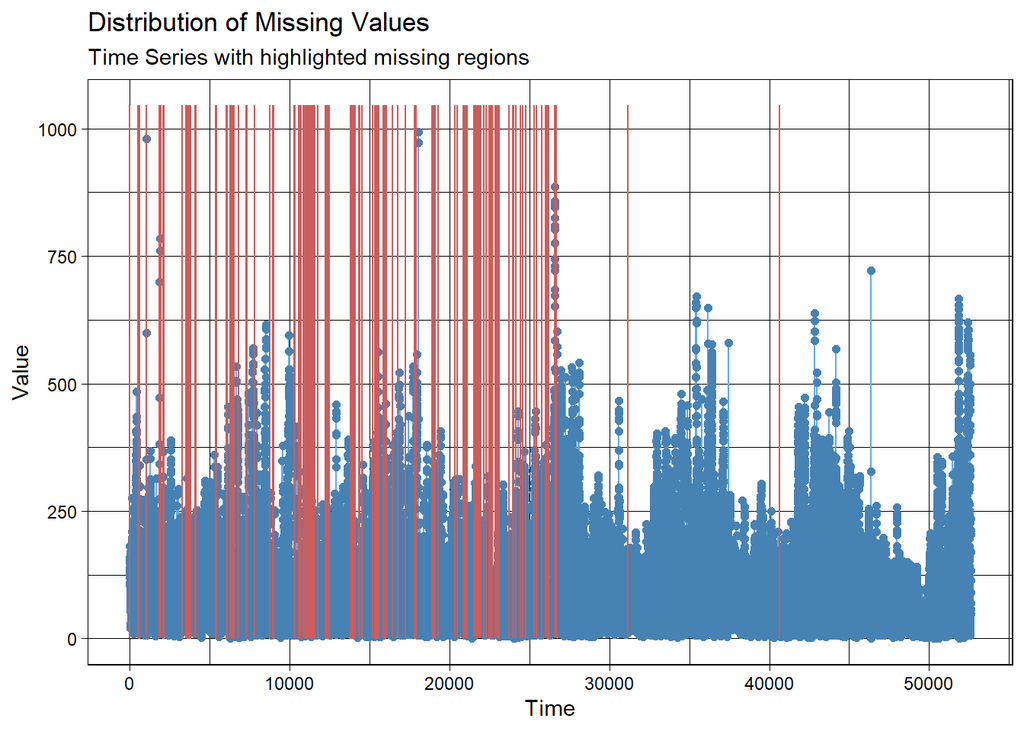

```r
# NA distribution PM25
ggplot_na_distribution(data$PM_US.Post)
```

```r
# Raggruppo per giorni
mydata <- mydata %>%
  group_by(date) %>%
  summarise(PM25 =mean(PM_US.Post,na.rm = TRUE), dew_point=mean(DEWP,na.rm = TRUE),
            humidity=mean(HUMI,na.rm = TRUE),pressure=mean(PRES,na.rm = TRUE),
            temperature=mean(TEMP,na.rm = TRUE),cum_windspeed=mean(Iws,na.rm = TRUE),
            precipitation=mean(precipitation,na.rm = TRUE),cum_precip=mean(Iprec,na.rm = TRUE))
head(mydata)
```

```
## # A tibble: 6 x 9
##   date                 PM25 dew_point humidity pressure temperature
##   <dttm>              <dbl>     <dbl>    <dbl>    <dbl>       <dbl>
## 1 2010-01-01 00:00:00 129       -18.8     38.5    1017.       -6.75
## 2 2010-01-02 00:00:00 144.       -8.5     77.9    1025.       -5.12
## 3 2010-01-03 00:00:00  78.4     -10.1     87.9    1023.       -8.54
## 4 2010-01-04 00:00:00  29.3     -20.9     46.2    1029.      -11.5
## 5 2010-01-05 00:00:00  43.5     -24.6     42.0    1034.      -14.5
## 6 2010-01-06 00:00:00  59.4     -23.7     39.2    1034.      -12.5
## # ... with 3 more variables: cum_windspeed <dbl>, precipitation <dbl>,
## #   cum_precip <dbl>
```

### Outliers

La ricerca di possibili outliers è stata fatta utilizzando i **Tukey fences** della funzione boxplot, la maggioranza delle variabili non ha presentato valori anomali, mentre **PM25** e **cum_windspeed** hanno valori che rappresentano la normale struttura dei dati e quindi non devono essere eliminati, solamente le variabili **precipitation** e **cum_precip**, che è una trasformazione della prima, hanno un valore anomalo che è stato eliminato.

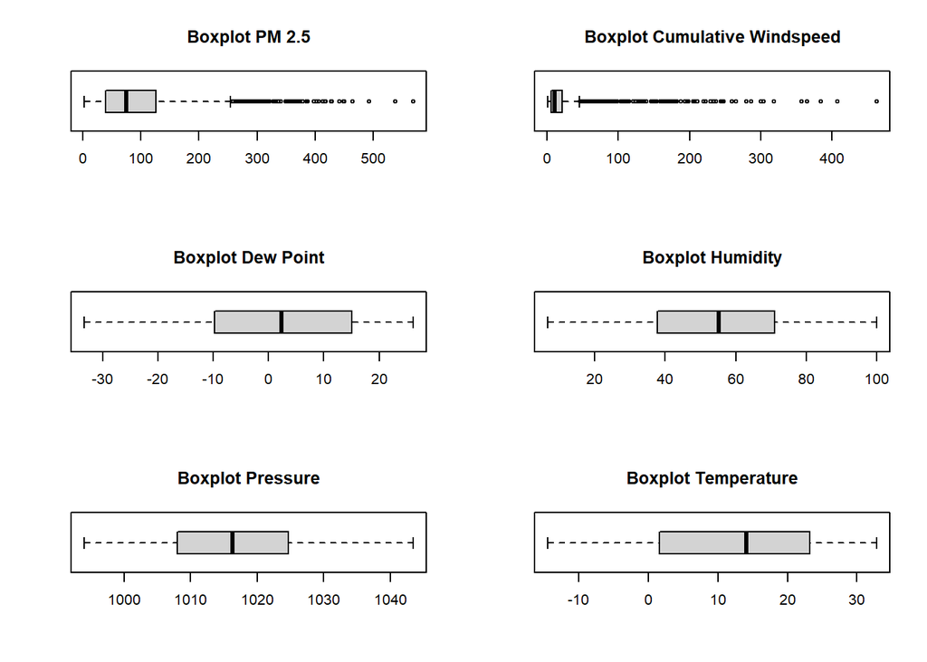

```r
# Outliers
par(mfrow=c(3,2))
# Normale struttura dati
boxplot(mydata[,'PM25'],horizontal = T,main="Boxplot PM 2.5")
boxplot(mydata[,'cum_windspeed'],horizontal = T,main="Boxplot Cumulative Windspeed")
# Nessun outlier
boxplot(mydata[,'dew_point'],horizontal = T,main="Boxplot Dew Point")
boxplot(mydata[,'humidity'],horizontal = T,main="Boxplot Humidity")
boxplot(mydata[,'pressure'],horizontal = T,main="Boxplot Pressure")
boxplot(mydata[,'temperature'],horizontal = T,main="Boxplot Temperature")
```

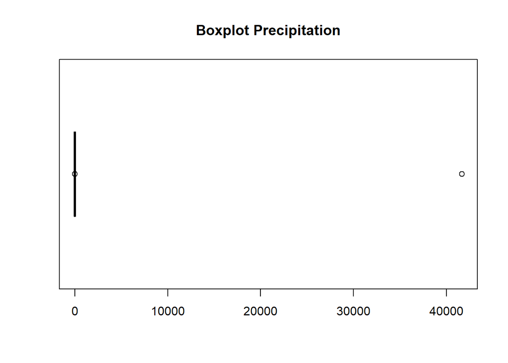

```r
boxplot(mydata[,'precipitation'],horizontal = T,main="Boxplot Precipitation")
```

```r
max(mydata[,'precipitation'],na.rm = TRUE)
```

```
## [1] 41666.35
```

```r
mydata[2137,"precipitation"] <- 0
mydata[2137,"cum_precip"] <- 0
```

### Classificazione PM 2.5

Utilizzando la **classificazione americana** sui limiti del particolato si è mostrato le categorie di riferimento presenti nel nostro dataset.  
Solo il **2.37%** è risultato con un livello accettabile, e meno del **20%** con un livello moderato, il **13.7%** è risultato non salutare per molte categorie sensibili. Invece, il **62.86%** presenta valori decisamente non salutari.

```r
categ <- cut(round(mydata$PM25,1),breaks = c(-Inf,12.0,35.4,55.4,150.4,250.4,+Inf),
                    labels = c("Good","Moderate","Unhealthy(*groups)","Unhealthy","Very unhealthy","Hazardous"))
round(table(categ)/length(mydata$PM25)*100,2)
```

```
## categ
##               Good           Moderate Unhealthy(*groups)          Unhealthy
##               2.37              19.35              13.78              44.32
##     Very unhealthy          Hazardous
##              13.51               5.02
```

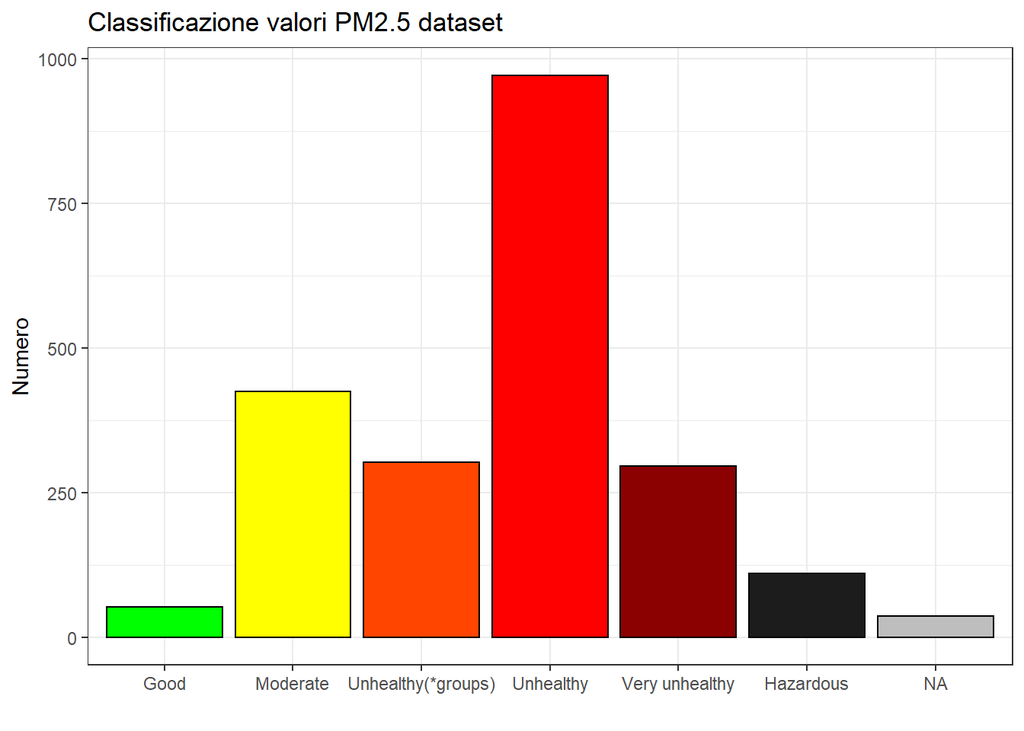

```r
categ <- as.data.frame(categ)
colr <- c("green","yellow","orangered1","red","red4","grey11","grey")
ggplot(categ)+geom_bar(aes(x=categ),fill=colr,col="black")+theme_bw() + ggtitle("Classificazione valori PM2.5 dataset")+
  ylab("Numero")+xlab("")
```

### Correlazione

Data la natura dei nostri dati è d’aiuto osservare le correlazioni tra le variabili del dataset.

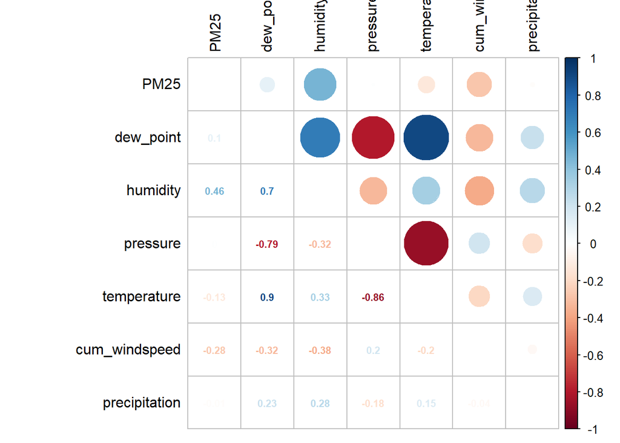

```r
corr <- cor(mydata[,2:8],use="complete.obs")
corrplot.mixed(corr,tl.col="black", tl.pos = "lt", number.cex = .7)
```

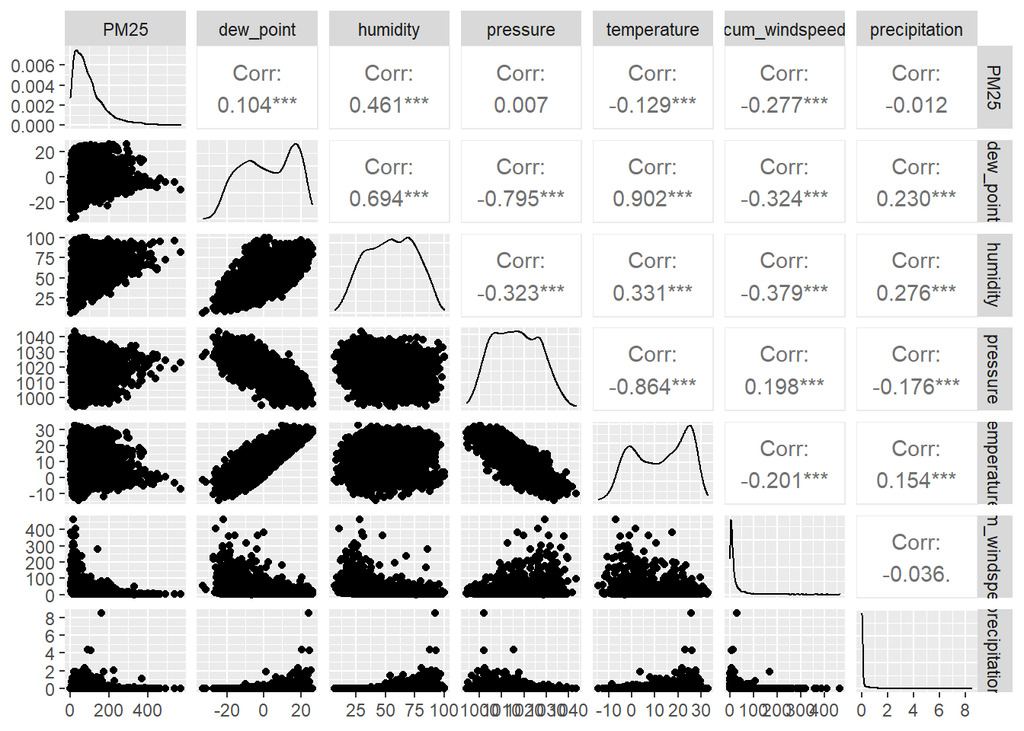

```r
GGally::ggpairs(mydata[,2:8])
```

## Time series

```r
tsdata <- ts(mydata,start = 2010,frequency = 365.25)
sommaNA <- rep(1,8)
for (i in 2:9)
{
  sommaNA[i] <- sum(is.na(tsdata[,i]))
}
names(sommaNA) <- colnames(tsdata)
sommaNA
```

```
##          date          PM25     dew_point      humidity      pressure
##             1            36             0            11            11
##   temperature cum_windspeed precipitation    cum_precip
##             0             0             8             8
```

```r
# Ci sono ancora 36 NA in PM25
statsNA(tsdata[,"PM25"])
```

```
## [1] "Length of time series:"
## [1] 2191
## [1] "-------------------------"
## [1] "Number of Missing Values:"
## [1] 36
## [1] "-------------------------"
## [1] "Percentage of Missing Values:"
## [1] "1.64%"
## [1] "-------------------------"
## [1] "Number of Gaps:"
## [1] 18
## [1] "-------------------------"
## [1] "Average Gap Size:"
## [1] 2
## [1] "-------------------------"
```

[output cut: 21 more lines]

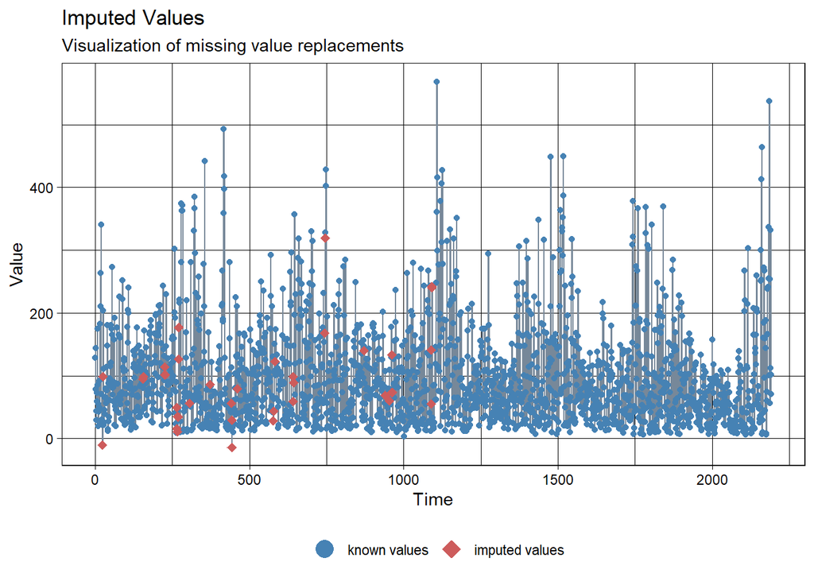

```r
# Imputazione con la Media
tsdata1 <- na_seadec(tsdata)
ggplot_na_imputations(tsdata[,"PM25"],tsdata1[,"PM25"])
```

### Componenti della serie

Durante l’analisi di serie storiche è di primaria importantanza analizzare le componenti della serie che possono essere:

- **trend**: cambiamento positivo o negativo, in un periodo prolungato nel livello medio della serie.
- **stagionalità**: cambiamenti periodici in un intervallo di tempo regolare.
- **ciclicità**: cambiamenti non periodici nella serie. Il resto delle variazioni è attribuibile ad effetti **irregolari**.

La nostra serie storica dal grafico riportato non ha sicuramente un trend, mentre è possibile notare dei picchi **regolari** all’inizio/fine di ogni anno, con una magnitudo dell’effetto variabile, questo potrebbe riferirsi alla presenza di **stagionalità** a causa di effetti temporali, come la stagione invernale.

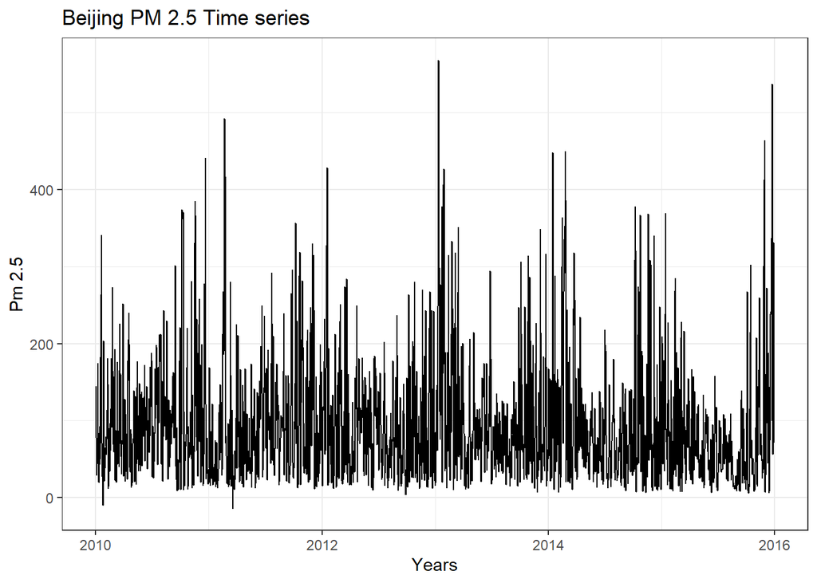

```r
autoplot(tsdata1[,"PM25"],xlab= "Years",ylab="Pm 2.5",main="Beijing PM 2.5 Time series")+theme_bw()
```

In particolare, prendendo un sotto-insieme per gli anni 2014 e 2015:

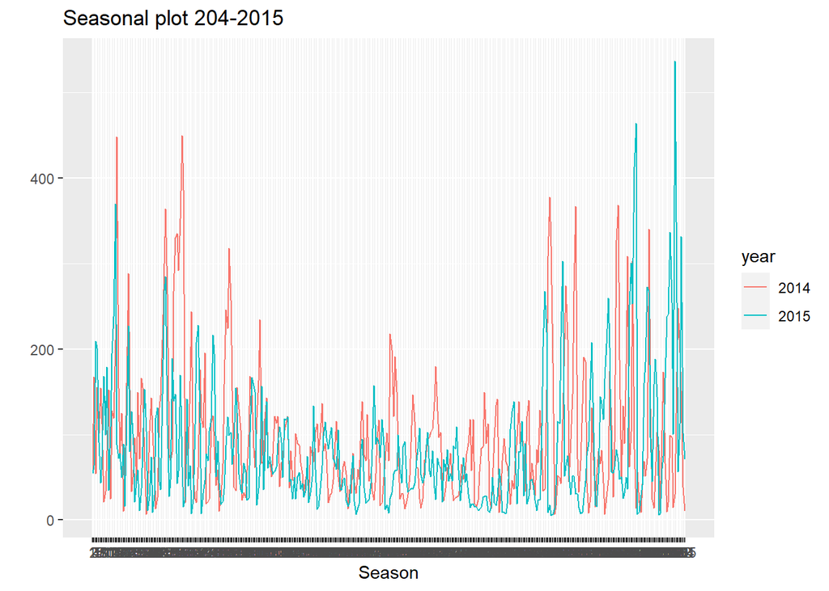

```r
# 2 anni
a1 <- window(tsdata1[,"PM25"],start=2014)
ggseasonplot(a1,main="Seasonal plot 204-2015")
```

### Stazionarietà e Auto-correlazione

Il grafico della serie ci permette di fare considerazioni anche riguardo la **stazionarietà**, essa è definita come una caratteristica delle serie in cui le loro proprietà statistiche non cambiano nel tempo e indipendentemente da quando viene osservata. Nel nostro caso, la componente stagionale fa si che la stazionarietà **non sia rispettata**. Uno dei mezzi per osservarla meglio è utilizzando l’**auto-correlazione campionaria**, intesa come il legame lineare tra i valori ritardati di una stessa serie. Nello specifico, utilizzando il **correlogramma ACF** è possibile vedere queste auto correlazioni.

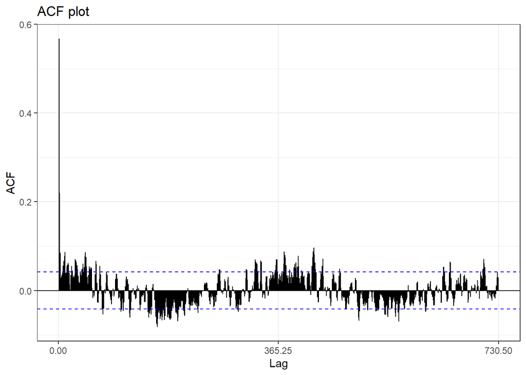

```r
ggAcf(tsdata1[,"PM25"])+ ggtitle("ACF plot")+ theme_bw()
```

## Modelli standard

Uno dei maggiori obiettivi quando si analizzano delle serie storiche è quello di **fare previsioni**, in questo paragrafo applicheremo prima di tutto i principali metodi di previsione che vengono utilizzati come **benchmark**, tra cui:

- **Average Method**: la previsione dei dati si basa sulla media dei valori della serie storica.

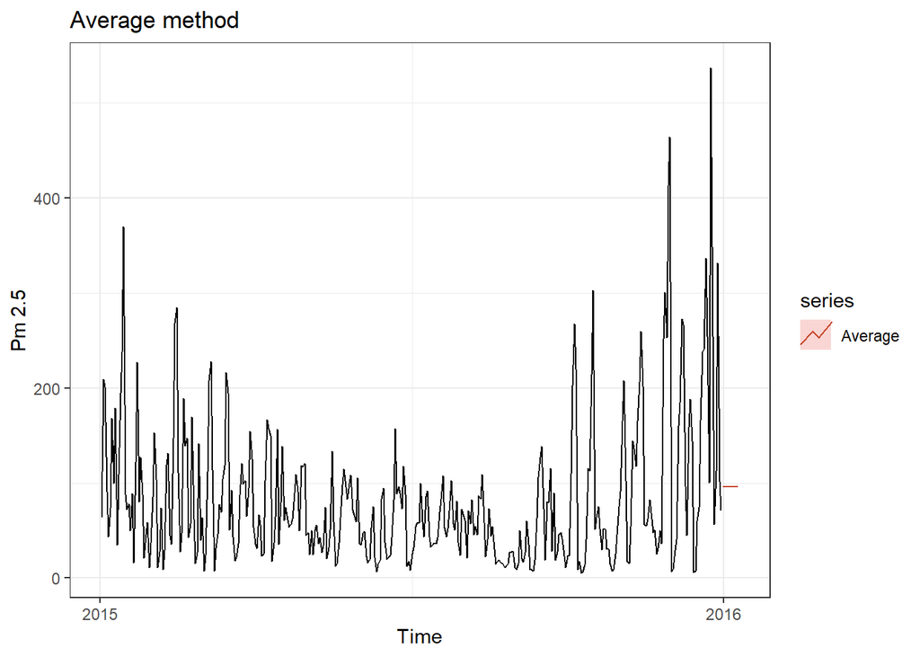

```r
# Average method
a2 <- window(tsdata1[,"PM25"], start=2015)

mf <- meanf(tsdata1[,"PM25"])
autoplot(a2) + autolayer(mf, series="Average", PI=FALSE)+theme_bw() + ggtitle("Average method")+
  ylab("Pm 2.5")
```

- **Naive method**: la previsione dei dati si basa sull’ultima osservazione osservata.

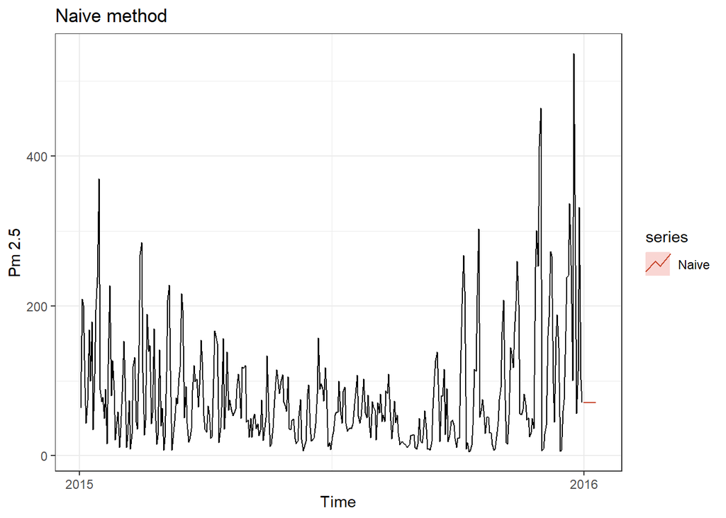

```r
# Naive method
nv <- naive(tsdata1[,"PM25"])
autoplot(a2) + autolayer(nv, series="Naive", PI=FALSE)+theme_bw() + ggtitle("Naive method")+
  ylab("Pm 2.5")
```

- **Drift Method**: simile al metodo Naive ma le previsioni possono crescere o decrescere, e sono ottenute come variazioni medie dei valori osservati.

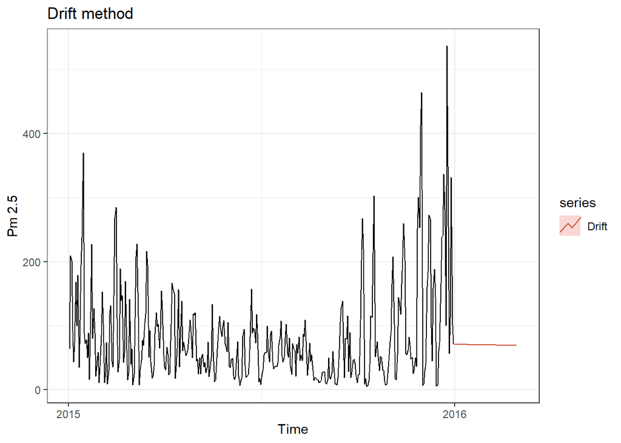

```r
# Drift method
drift <- rwf(tsdata1[,"PM25"],60,drift = TRUE)
autoplot(a2) + autolayer(drift, series="Drift", PI=FALSE)+theme_bw() + ggtitle("Drift method")+
  ylab("Pm 2.5")
```

- **Seasonal Naive method**: metodo Naive applicato a dati stagionali, in cui le previsioni si riferiscono al periodo “stagionale” precedente. Le previsioni generate sono state ottenute per un periodo futuro di 30 giorni.

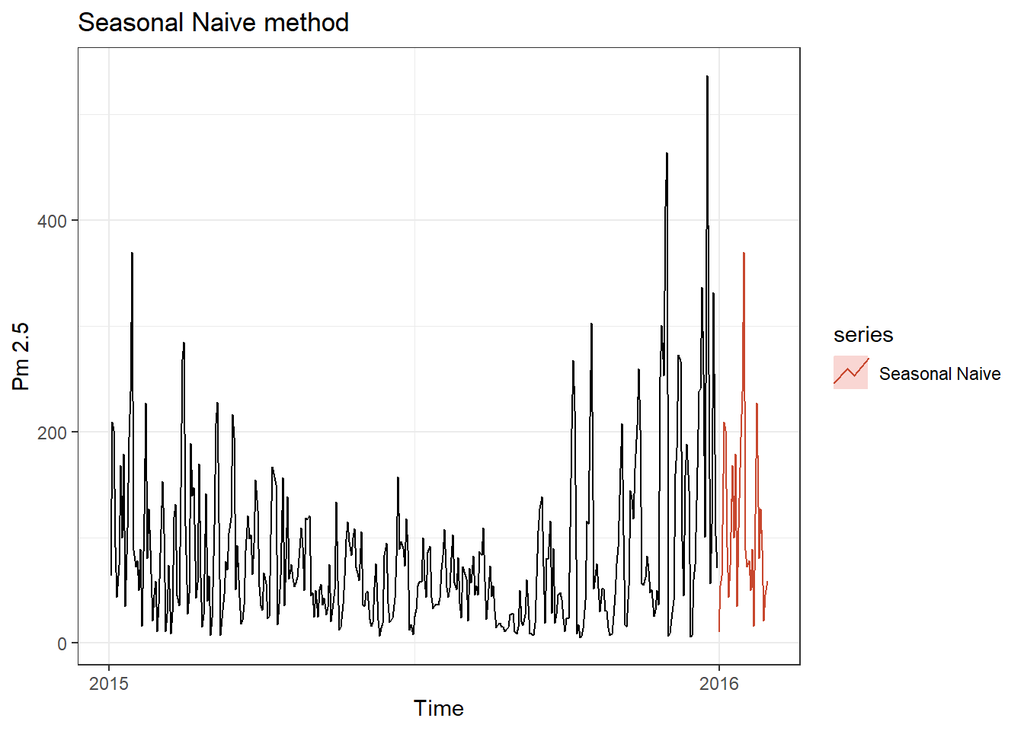

```r
# Applicazione manuale del seasonal naive
T=length(tsdata1[,"PM25"])
h=1:60
m=frequency(tsdata1[,"PM25"])
k=floor((h-1)/m)
# snv <- tsdata1[,"PM25"][T+h-(m*(k+1))]

# Funzione Seasonal Naive method
snv <- snaive(tsdata1[,"PM25"],30)
autoplot(a2) + autolayer(snv, series="Seasonal Naive", PI=FALSE)+theme_bw() + ggtitle("Seasonal Naive method")+ylab("Pm 2.5")
```

**Confronto tra i metodi**

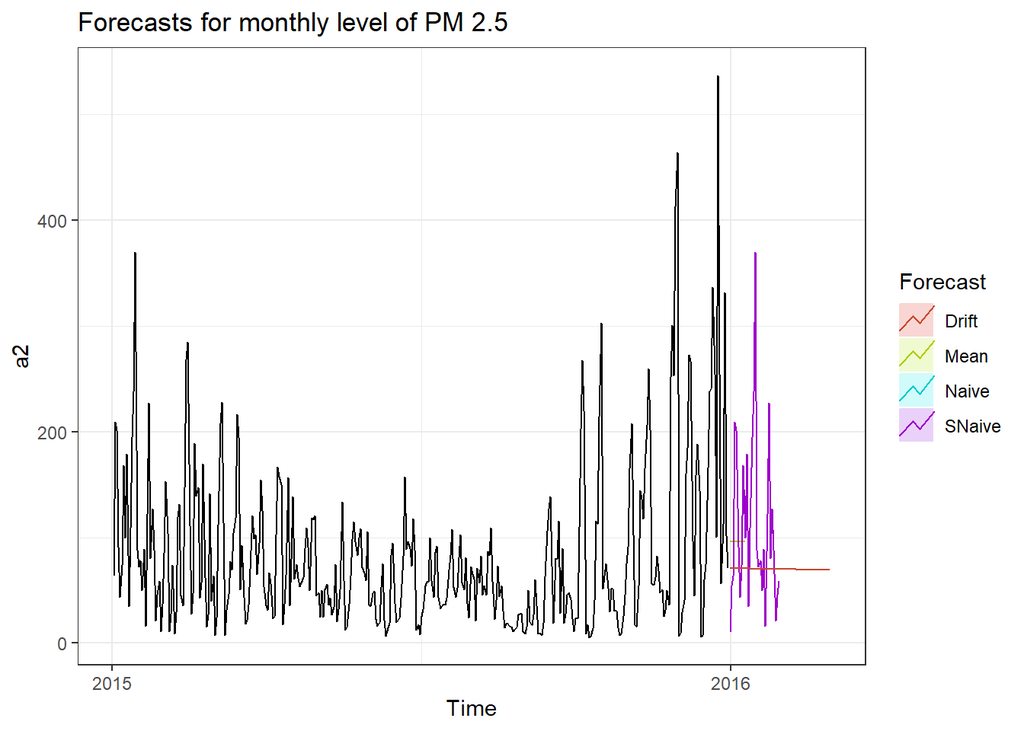

```r
autoplot(a2) +
  autolayer(mf, PI=FALSE,series="Mean") +
  autolayer(nv, PI=FALSE, series="Naive") +
  autolayer(snv, PI=FALSE, series="SNaive") +
  autolayer(drift, series="Drift", PI=FALSE) +
  guides(colour=guide_legend(title="Forecast")) +
  ggtitle("Forecasts for monthly level of PM 2.5")+
  theme_bw()
```

N.B: Per la nostra serie, la variazione tra i metodi Naive e Drift è poco visibile sul grafico.

## Trasformazioni

### Box-Cox

Le trasformazioni matematiche sono particolarmente utili quando si utilizzano serie storiche con diversi livelli e in particolare per quelle **non stazionarie**, come nel nostro caso. L’esempio più noto è la **trasformazione di Box-Cox** appartente alla famiglia di trasformazioni di potenza, che può essere ricondotta anche ad una trasformazione **logaritmica** utilizzando in modo opportuno il parametro **lambda**.  
Lo scopo di questa trasformazione è di rendere la distribuzione della serie più simile a quella della normale, riducendo l’asimmetria.

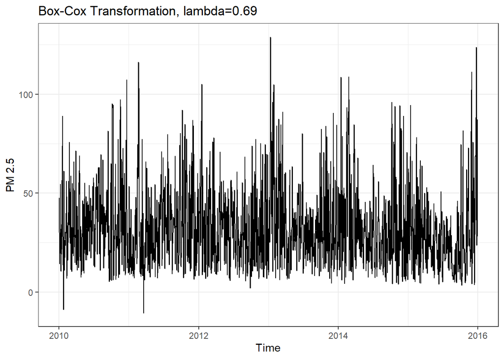

```r
# Trasformazione di Box-Cox
lambda <- BoxCox.lambda(tsdata1[,"PM25"])
autoplot(BoxCox(tsdata1[,"PM25"],lambda),main="Box-Cox Transformation, lambda=0.69", ylab="PM 2.5")+
  theme_bw()
```

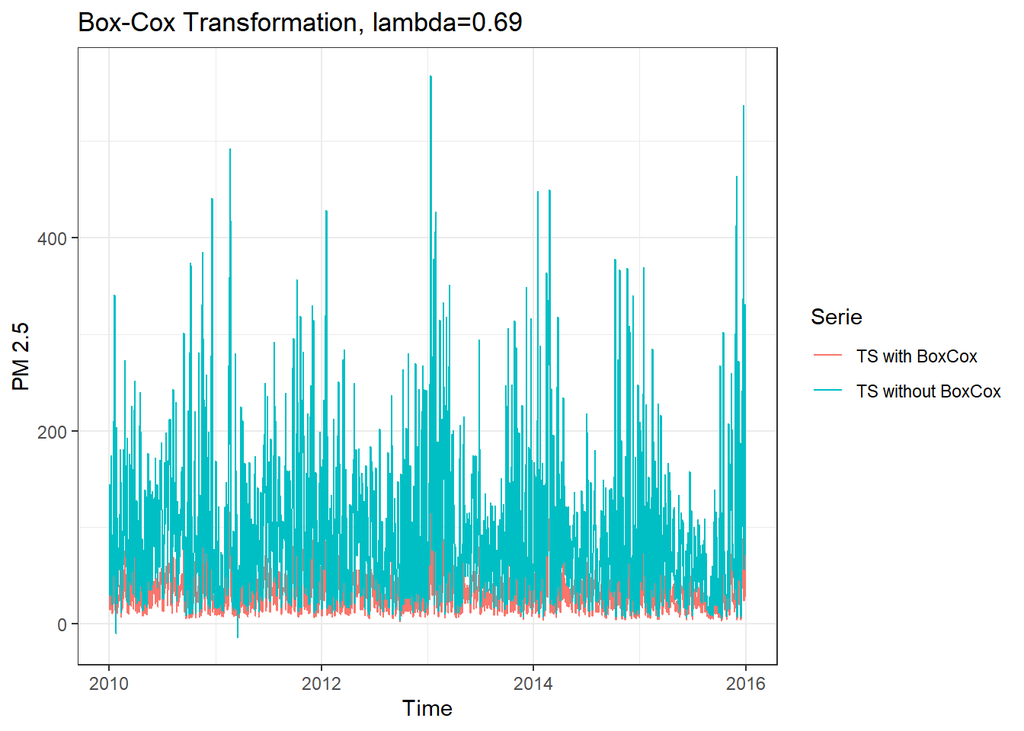

```r
autoplot(BoxCox(tsdata1[,"PM25"],lambda),main="Box-Cox Transformation, lambda=0.69", ylab="PM 2.5",series="TS with BoxCox")+
autolayer(tsdata1[,"PM25"],series = "TS without BoxCox") + theme_bw() + guides(colour=guide_legend(title = "Serie"))
```

```r
# Dati trasformati
lambda <- BoxCox.lambda(tsdata1[,"PM25"])
tData <- BoxCox(tsdata1[,"PM25"],lambda)
tData1 <- BoxCox(tsdata1,lambda)
```

### Back-transformation e Bias Adjustment

Utilizzare delle trasformazioni su una serie fa si che i modelli vengono stimati su i dati transformati e quindi è necessario che le previsioni e gli intervalli debbano essere riconvertiti sulla scala dei **dati originali**, per questo motivo è importante utilizzare la **back transformation**.  
Nel caso della Box-Cox essa viene fatto semplicemente con la sua **funzione inversa** ma le previsioni puntuali si basano sulla **mediana** della distribuzione di previsioni e non più sulla **media**. Questo è importante in caso si vogliano utilizzare previsioni **aggregate**, ad esempio su base mensile. Questa correzione è chiamata **bias adjustment**.

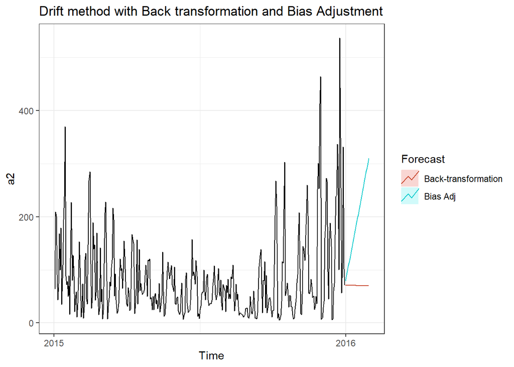

```r
# Bias adjustment
drift1 <- rwf(tsdata1[,"PM25"],30,lambda="auto",drift = TRUE)
drift2 <- rwf(tsdata1[,"PM25"],30,lambda="auto",drift= TRUE, biasadj = TRUE)
autoplot(a2,main="Drift method with Back transformation and Bias Adjustment") +
  autolayer(drift1, series="Back-transformation", PI=FALSE)+
  autolayer(drift2,PI=FALSE,series="Bias Adj")+
  guides(colour=guide_legend(title="Forecast")) + theme_bw()
```

## Analisi dei residui

L’analisi dei residui ci permette di verificare se il nostro modello ha catturato la maggior parte delle informazioni dei dati. Esso è costruito come la differenza tra i dati osservati e i valori stimati dal modello.  
Le proprietà desiderabili per i residui di un buon modello sono:

- **Residui incorrelati**: se i residui sono correlati ci sono informazioni che sono state tralasciate.
- **Residui con media zero**: diversamente le previsioni saranno distorte.
- **Residui con varianza costante**: per avere dei migliori intervalli di previsione.
- **Residui con distribuzione normale**.

Le diagnostiche che si utilizzano sono il correlogramma ACF, per vedere la correlazione tra i residui, e il **test di Ljung-Box**, per testare formalmente che la correlazione sia zero.

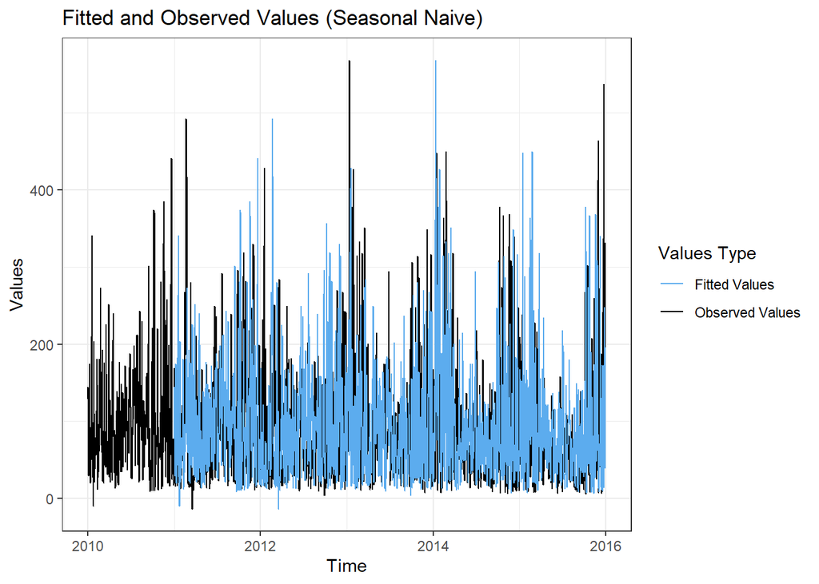

```r
#
fitt <- fitted(snaive(tsdata1[,"PM25"],h = 10,lambda = "auto"))
autoplot(tsdata1[,"PM25"],ylab="Values",series = "Observed Values",main = "Fitted and Observed Values (Seasonal Naive)") +
  autolayer(fitt,series = "Fitted Values")+
  theme_bw() +  scale_colour_manual(values = c("steelblue2", "black")) + guides(colour=guide_legend(title="Values Type"))
```

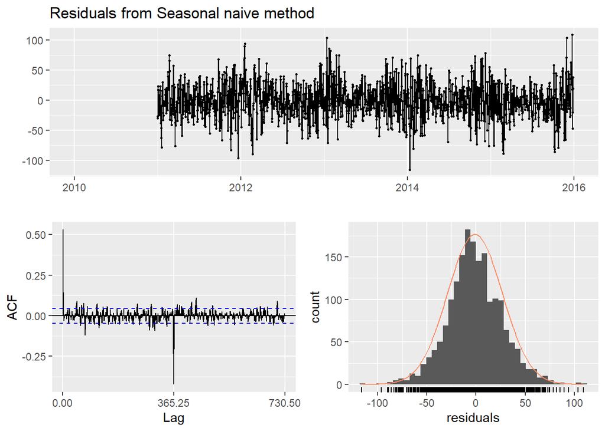

```
##
##  Ljung-Box test
##
## data:  Residuals from Seasonal naive method
## Q* = 2287.8, df = 438, p-value < 2.2e-16
##
## Model df: 0.   Total lags used: 438
```

```r
checkresiduals(snaive(tsdata1[,"PM25"],h = 10,lambda = "auto"))
```

Si può vedere nel grafico riassuntivo che la varianza dei residui è abbastanza costante intorno lo zero e la loro distribuzione è molto simile ad una normale; nell’ACF, invece, è evidente che la correlazione non è zero soprattutto per i valori di 1 e 365 giorni, la conferma è possibile averla anche nel test di Ljung-Box che rifiuta l’ipotesi nulla con un **p-value** molto basso.

**NB:** E’ importante ricordare che nell’analisi di serie storiche è facile trovare autocorrelazione nei residui, in questo caso le previsioni saranno inefficienti ma sono non-distorte e non sono “sbagliate” ma si avranno intervalli di previsione più grandi del normale.

## Accuratezza delle previsioni

- **Mean Absolute Error**:
  $$MAE = mean(|e_{T+h}|)$$
- **Root Mean Squared Error**:
  $$RMSE = \sqrt{mean(e_{T+h}^2)}$$
  Essi misurano la variabilità degli errori, il primo utilizzando il valore assoluto e il secondo utilizzando una funzione quadratica.

Altri indici che non dipendono dalla scala dei dati sono:

- **Mean Absolute Percentage Error**:
  $$MAPE= mean(|p_t|)$$
  con $p_t= \frac{e_{T+h}}{y_{T+h}}*100$

Utilizzato soprattutto per il confronto tra diverse serie ma che risulta indefinito per valori di $y_t=0$ e assume valori estremi per valori di y vicini a zero.

- **Mean Absolute Scaled Error**:
  $$MASE= mean(|e_{T+h}|/C)$$

Si basa sugli **errori riscalati**, anch’esso per il confronto tra serie con scale diverse, alternativo agli errori percentuali del MAPE.

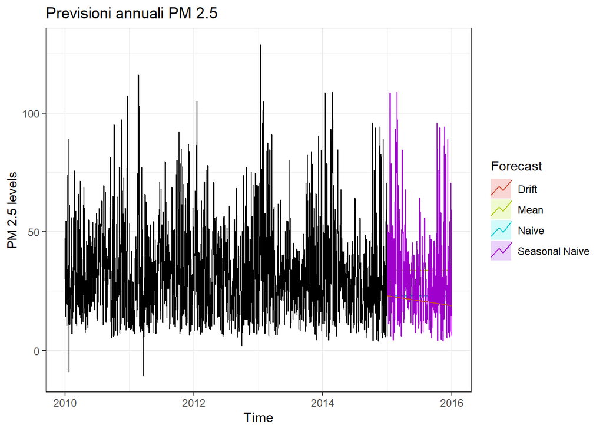

```r
train_set <- window(tData, start=2010,end=2015)

ts_fit1 <- meanf(train_set,h=365)
ts_fit2 <- rwf(train_set,h=365)
ts_fit3 <- snaive(train_set,h=365)
ts_fit4 <- rwf(train_set,h=365,drift = TRUE)

# Previsioni per l'ultimo anno
autoplot(train_set) + autolayer(ts_fit1,PI=FALSE,series="Mean") +
  autolayer(ts_fit2,PI=FALSE,series="Naive")+autolayer(ts_fit3,PI=FALSE,series="Seasonal Naive")+autolayer(ts_fit4,PI=FALSE,series="Drift")+
  guides(colour=guide_legend(title="Forecast")) + ggtitle("Previsioni annuali PM 2.5 ")+
  theme_bw() + ylab("PM 2.5 levels")
```

```r
test_set <- window(tsdata1[,"PM25"], start= 2015, end=2015.996)
ind <- c(2,3,5,6)

Average <- accuracy(ts_fit1,test_set)[2,ind] # mean
Naive <- accuracy(ts_fit2,test_set)[2,ind] # naive
SeasNaive <- accuracy(ts_fit3,test_set)[2,ind] # seasonal naive
Drift <- accuracy(ts_fit4,test_set)[2,ind] # drift
tb <- rbind(Average,Naive,SeasNaive,Drift)
tb
```

```
##               RMSE      MAE     MAPE     MASE
## Average   90.68575 56.82190 72.07163 2.627638
## Naive     96.90788 62.70861 66.99430 2.899860
## SeasNaive 93.23632 59.65175 81.61812 2.758501
## Drift     98.28873 64.02549 66.47295 2.960757
```

### Time Series Cross-Validation

Un metodo automatico per scegliere la miglior combinazione tra training e test set è la **cross-validation**. In questo metodo, il test set è costituito da una sola osservazione e il training set dalle altre osservazioni precedenti che sono utilizzate per la costruzione della previsione. L’osservazione del test set si sposta avanti nel tempo e viene calcolato l’indice di accuratezza scelto, nel nostro caso l’RMSE.

```r
e <- tsCV(tData,rwf,h=365,initial = 1825)
rmse <- sqrt(colMeans(e^2, na.rm = T))
rmse
```

```
##      h=1      h=2      h=3      h=4      h=5      h=6      h=7      h=8
## 17.94969 24.23383 25.88810 26.61304 26.83855 26.89305 26.47601 25.75798
##      h=9     h=10     h=11     h=12     h=13     h=14     h=15     h=16
## 24.81330 24.25624 24.14514 24.61207 25.14785 25.64720 25.66554 25.30550
##     h=17     h=18     h=19     h=20     h=21     h=22     h=23     h=24
## 25.52095 25.38233 24.55535 25.00759 25.20229 25.21517 25.47727 24.09390
##     h=25     h=26     h=27     h=28     h=29     h=30     h=31     h=32
## 23.21248 23.72461 23.66547 22.83815 23.10167 24.30439 25.36342 25.44902
##     h=33     h=34     h=35     h=36     h=37     h=38     h=39     h=40
## 25.73423 25.60536 25.27144 24.85613 24.65910 24.31634 24.23594 24.30298
##     h=41     h=42     h=43     h=44     h=45     h=46     h=47     h=48
## 23.80501 23.64158 24.25092 24.24150 24.57755 24.91245 25.37903 25.70244
##     h=49     h=50     h=51     h=52     h=53     h=54     h=55     h=56
## 25.33515 25.29565 24.61256 24.17142 23.77560 23.59273 23.35891 24.08743
##     h=57     h=58     h=59     h=60     h=61     h=62     h=63     h=64
## 25.21756 25.68834 26.52322 26.20269 25.44874 25.27811 25.10026 25.27738
##     h=65     h=66     h=67     h=68     h=69     h=70     h=71     h=72
## 25.42942 24.76382 24.41344 24.62922 24.63223 24.70240 24.99815 25.24976
##     h=73     h=74     h=75     h=76     h=77     h=78     h=79     h=80
## 25.26969 25.09927 24.73488 24.40989 24.94896 26.16106 26.16011 25.87603
##     h=81     h=82     h=83     h=84     h=85     h=86     h=87     h=88
## 25.76049 25.62079 25.36440 25.45199 25.23969 25.42807 25.77471 25.98129
##     h=89     h=90     h=91     h=92     h=93     h=94     h=95     h=96
## 26.56178 25.89594 25.46920 25.58716 26.01072 26.44548 26.26353 25.80550
##     h=97     h=98     h=99    h=100    h=101    h=102    h=103    h=104
## 26.06609 26.15011 26.00947 25.12348 25.19455 25.32687 25.55405 25.67481
##    h=105    h=106    h=107    h=108    h=109    h=110    h=111    h=112
## 26.13418 26.48855 27.33728 27.42708 27.19917 26.79805 26.41583 26.10593
##    h=113    h=114    h=115    h=116    h=117    h=118    h=119    h=120
## 26.23943 26.37947 26.34259 26.68094 27.28600 27.45466 27.97007 27.82784
##    h=121    h=122    h=123    h=124    h=125    h=126    h=127    h=128
## 27.65793 27.28192 27.21624 27.26739 27.62239 27.66968 26.72331 25.91856
##    h=129    h=130    h=131    h=132    h=133    h=134    h=135    h=136
## 25.79188 26.08997 26.79888 26.44386 25.65471 25.37679 26.57534 27.64273
##    h=137    h=138    h=139    h=140    h=141    h=142    h=143    h=144
## 27.63740 27.12593 26.76452 26.01373 25.54466 25.14712 26.38858 27.14122
##    h=145    h=146    h=147    h=148    h=149    h=150    h=151    h=152
## 27.34053 27.06219 27.97675 28.68130 28.99259 29.12703 28.51330 27.55458
##    h=153    h=154    h=155    h=156    h=157    h=158    h=159    h=160
## 27.63992 28.25755 28.12184 27.78169 27.42869 27.43527 27.47051 27.82658
```

[output cut: 37 more lines]

```
## 38.63559 38.68827 37.94398 35.14502 31.20849 33.43568 35.60976 36.97726
##    h=313    h=314    h=315    h=316    h=317    h=318    h=319    h=320
## 37.41170 37.63432 38.73596 40.07916 38.39149 36.27417 34.36589 35.07744
##    h=321    h=322    h=323    h=324    h=325    h=326    h=327    h=328
## 39.32122 39.19024 40.34177 42.88699 40.91590 40.51627 39.86442 39.72156
##    h=329    h=330    h=331    h=332    h=333    h=334    h=335    h=336
## 41.13321 38.88750 38.40214 41.30468 41.84375 42.78288 45.17344 39.00255
##    h=337    h=338    h=339    h=340    h=341    h=342    h=343    h=344
## 36.43839 36.06439 33.94702 34.45469 36.85573 38.94299 35.60671 28.19843
##    h=345    h=346    h=347    h=348    h=349    h=350    h=351    h=352
## 32.11851 38.28108 39.85664 38.79215 35.29312 37.53187 35.91990 39.26474
##    h=353    h=354    h=355    h=356    h=357    h=358    h=359    h=360
## 41.25309 45.47216 41.05884 41.73560 48.22358 47.84585 50.08185 30.94622
##    h=361    h=362    h=363    h=364    h=365
## 34.86208 40.45590 47.55276 21.92502 21.92344
```

### Intervalli di previsione

Calcoliamo gli intervalli di previsione per il metodo Naive in cui la deviazione standard è ottenuta come: $\hat{\sigma_h}=\hat{\sigma}\sqrt{h}$ è l’intervallo di previsione come: $\hat{y_{T+h|h}} \pm 1.96\hat{\sigma_h}$. Supponendo che gli intervalli abbiano distribuzione normale e che la previsione sia h-step, inoltre gli intervalli di previsione, se i dati sono stati trasformati, devono essere ri-trasformati sulla scala originale, ricordando come già detto nei paragrafi precedenti che gli intervalli non saranno più simmetrici.

```r
rwf(train_set,h=365,level = 95,lambda = "auto")
```

[output not shown]

[output cut: 311 more lines]

```
## 2015.9603       23.00583 -5.029393e+03 7947.98802
## 2015.9630       23.00583 -5.048356e+03 7972.73631
## 2015.9658       23.00583 -5.067334e+03 7997.49418
## 2015.9685       23.00583 -5.086326e+03 8022.26162
## 2015.9713       23.00583 -5.105333e+03 8047.03861
## 2015.9740       23.00583 -5.124355e+03 8071.82513
## 2015.9767       23.00583 -5.143390e+03 8096.62117
## 2015.9795       23.00583 -5.162440e+03 8121.42670
## 2015.9822       23.00583 -5.181505e+03 8146.24171
## 2015.9849       23.00583 -5.200583e+03 8171.06618
## 2015.9877       23.00583 -5.219676e+03 8195.90010
## 2015.9904       23.00583 -5.238784e+03 8220.74344
## 2015.9932       23.00583 -5.257905e+03 8245.59619
## 2015.9959       23.00583 -5.277041e+03 8270.45833
## 2015.9986       23.00583 -5.296190e+03 8295.32985
```

## Modello di regressione per serie storiche

Utilizzando le variabile presenti nel nostro dataset è possibile costruire un **modello di regressione lineare multiplo** per valutare l’effetto dei predittori sulla variabile risposta. Formalmente:
$$y_t = \beta_0 + \beta_1 x_{1,t}+ \beta_2 x_{2,t} + .. + \beta_j x_{j,t} + e_t$$

```r
fit1 <- tslm(PM25 ~ dew_point + temperature + cum_windspeed + pressure + humidity + precipitation , data = tData1)
summary(fit1)
```

```
##
## Call:
## tslm(formula = PM25 ~ dew_point + temperature + cum_windspeed +
##     pressure + humidity + precipitation, data = tData1)
##
## Residuals:
##     Min      1Q  Median      3Q     Max
## -51.749 -10.170  -1.720   8.214  66.967
##
## Coefficients:
##                Estimate Std. Error t value Pr(>|t|)
## (Intercept)   877.90840   87.30346  10.056   <2e-16 ***
## dew_point      -1.94248    0.19473  -9.975   <2e-16 ***
## temperature     0.27384    0.20044   1.366    0.172
## cum_windspeed  -0.26481    0.03019  -8.773   <2e-16 ***
## pressure       -4.68905    0.44611 -10.511   <2e-16 ***
## humidity        2.70828    0.12847  21.081   <2e-16 ***
## precipitation -10.17459    1.01315 -10.042   <2e-16 ***
## ---
## Signif. codes:  0 '***' 0.001 '**' 0.01 '*' 0.05 '.' 0.1 ' ' 1
##
## Residual standard error: 15.3 on 2184 degrees of freedom
## Multiple R-squared:  0.4046, Adjusted R-squared:  0.403
## F-statistic: 247.4 on 6 and 2184 DF,  p-value: < 2.2e-16
```

I **coefficienti** delle variabili indipendenti $\beta_j$ mostrano l’effetto di un loro aumento unitario sulla variabile risposta, considerando fisse tutte le altre variabili. Gli **standard error** mostrano la variabilità dei coefficienti stimati e il **p-value** che ci permette di valutare la significatività del parametro più velocemente, molto importante per valutare l’effetto del predittore ma non molto utile per calcolare la previsione.

Durante la formulazione di un modello di regressione si considerano rispettate le **assunzioni classiche** che riguardano:

- modello correttamente specificato
- $E[e_i]=0$
- Errori non autocorrelati
- Errori non correlate alle variabili predittive

E come ipotesi aggiuntiva, utile per la formazione degli intervalli di previsione, è la normalità degli errori: $e_t \sim N(0,\sigma^2)$.

Possiamo vedere visivamente i valori fittati ottenuti dal modello utilizzando il metodo dei minimi quadrati rispetto i valori originali dei nostri dati.

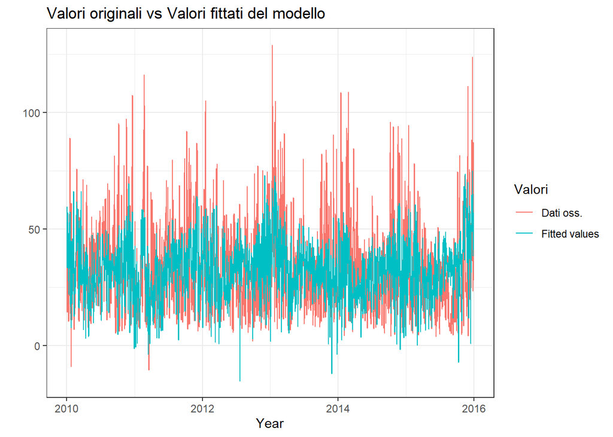

```r
autoplot(tData1[,"PM25"],series="Dati oss.") + autolayer(fitted(fit1),series = "Fitted values")+
  xlab("Year") + ylab("") +
  ggtitle("Valori originali vs Valori fittati del modello") +
  guides(colour=guide_legend(title="Valori")) + theme_bw()
```

A questo punto possiamo valutare il nostro modello analizzando i residui del modello e la bontà di adattamento. Quest’ultima è osservabile attraverso l’indice $R^2$ presente nel summary precedente, definito come la quota di variabilità spiegata dal nostro modello rispetto la variabilità totale dei dati.

L’analisi dei residui ci permette di valutare il nostro modello; la loro media è abbastanza costante intorno allo zero, la distribuzione è simile ad una normale ma sembra esserci una piccola asimmetria positiva nei dati ed infine i residui sono seriamente autocorrelati, la conferma formale è possibile averla attraverso il **test di Breusch-Godfrey**, che è simile a quello di Ljung-Box ma costruito **ad hoc** per i modelli di regressione.

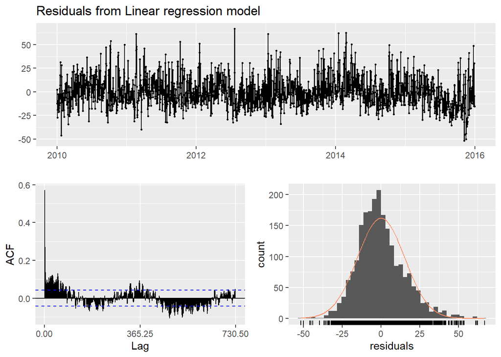

```
##
##  Breusch-Godfrey test for serial correlation of order up to 438
##
## data:  Residuals from Linear regression model
## LM test = 1009.2, df = 438, p-value < 2.2e-16
```

```r
checkresiduals(fit1)
```

### Possibili outliers nel modello

Una volta stimato il modello è possibile che siano presenti dei *possibili* outlier che influenzano il modello in modo maggiore rispetto le altre osservazioni. Possiamo vederli più da vicino valutando i residui studentizzati, gli hat values e la distanza di Cook. I valori di riferimento per la presenza di outlier sono:

- Studentized Residuals $>|2|$
- Hat Values $> 2*k/n$
- Cook Distance $> 4/(n-k)$

```r
# hat values:
2*6/2191
```

```
## [1] 0.005476951
```

```r
# cook distance:
4/(2191-6)
```

```
## [1] 0.001830664
```

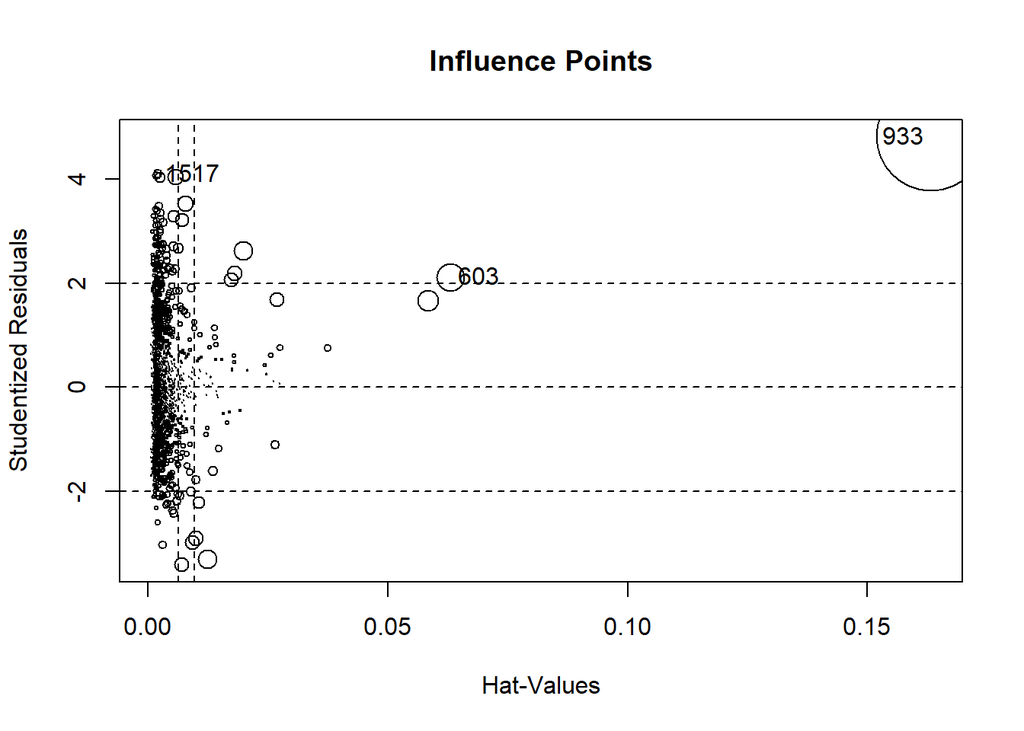

```
##       StudRes         Hat       CookD
## 603  2.113147 0.063066991 0.042871289
## 933  4.809518 0.163286342 0.638409576
## 1517 4.098330 0.001957213 0.004671699
```

```r
influencePlot(fit1, main="Influence Points")
```

### Serie di Fourier

Durante la stima di un modello spesso è utile inserire delle **variabili dummy** per poter cogliere gli effetti **stagionali**, in caso di periodi più lunghi inserire molte dummy è sconveniente ed è più utile inserire i **termini della serie di Fourier**, composti da una serie di coppie di seno e coseno che permettono di approssimare una funzione periodica.
Essa può essere particolarmente utile nel nostro caso dove il periodo è composto da 365 giorni.
$$s_k (t) = sin(\frac{2 \pi k t}{m})\space \space c_k (t) = cos(\frac{2 \pi k t}{m})$$

```r
fit2 <- tslm(PM25 ~ fourier(PM25,K=6) + dew_point + cum_windspeed + temperature + pressure + humidity + precipitation , data = tData1)
summary(fit2)
```

```
##
## Call:
## tslm(formula = PM25 ~ fourier(PM25, K = 6) + dew_point + cum_windspeed +
##     temperature + pressure + humidity + precipitation, data = tData1)
##
## Residuals:
##     Min      1Q  Median      3Q     Max
## -53.108  -8.599  -1.133   7.375  66.986
##
## Coefficients:
##                             Estimate Std. Error t value Pr(>|t|)
## (Intercept)                642.45724   93.76932   6.851 9.49e-12 ***
## fourier(PM25, K = 6)S1-365  13.71762    0.68055  20.157  < 2e-16 ***
## fourier(PM25, K = 6)C1-365  33.35851    1.80169  18.515  < 2e-16 ***
## fourier(PM25, K = 6)S2-365  -0.96939    0.43987  -2.204  0.02764 *
## fourier(PM25, K = 6)C2-365   2.75417    0.57833   4.762 2.04e-06 ***
## fourier(PM25, K = 6)S3-365  -0.07229    0.45612  -0.158  0.87408
## fourier(PM25, K = 6)C3-365   0.14958    0.44615   0.335  0.73746
## fourier(PM25, K = 6)S4-365  -0.49744    0.41958  -1.186  0.23592
## fourier(PM25, K = 6)C4-365   0.99689    0.41972   2.375  0.01763 *
## fourier(PM25, K = 6)S5-365  -1.27125    0.42200  -3.012  0.00262 **
## fourier(PM25, K = 6)C5-365   0.35668    0.41965   0.850  0.39545
## fourier(PM25, K = 6)S6-365  -0.17206    0.42130  -0.408  0.68302
## fourier(PM25, K = 6)C6-365   0.02131    0.41839   0.051  0.95938
## dew_point                    0.56327    0.25397   2.218  0.02667 *
## cum_windspeed               -0.17936    0.02798  -6.411 1.77e-10 ***
## temperature                  1.41807    0.26386   5.374 8.51e-08 ***
## pressure                    -3.42026    0.47421  -7.213 7.55e-13 ***
## humidity                     1.95199    0.14824  13.168  < 2e-16 ***
## precipitation               -7.70197    0.93170  -8.267 2.37e-16 ***
## ---
## Signif. codes:  0 '***' 0.001 '**' 0.01 '*' 0.05 '.' 0.1 ' ' 1
##
## Residual standard error: 13.83 on 2172 degrees of freedom
## Multiple R-squared:  0.5163, Adjusted R-squared:  0.5123
## F-statistic: 128.8 on 18 and 2172 DF,  p-value: < 2.2e-16
```

Possiamo confrontare i due modelli, con e senza termini di Fourier, utilizzando diversi misure come: il **criterio di informazione di Akaike** (normale e corretto) o il **criterio di informazione Bayesiano**, la **Cross-Validation** oppure l’indice $R^2$ **corretto**. Il miglior modello è quello che minimizza i primi tre, e massimizza l’ultimo.

```r
round(CV(fit1),2)
```

```
##       CV      AIC     AICc      BIC    AdjR2
##   235.71 11962.12 11962.19 12007.66     0.40
```

```r
round(CV(fit2),2)
```

```
##       CV      AIC     AICc      BIC    AdjR2
##   193.63 11531.00 11531.39 11644.85     0.51
```

### Previsioni con la regressione

Allo stesso modo degli altri tipi di modelli anche con il modello di regressione lineare è possibile fare previsioni, che possono dividersi in:

- **previsioni ex-ante**, realizzate utilizzando possibili valori futuri dei predittori.
- **previsioni ex-post**, in cui i valori dei predittori si conoscono in anticipo e si valuta il modello di previsione utilizzato.  
  Per le nostre previsioni abbiamo stimato le previsioni per l’ultimo anno di emissioni di particolato sul modello normale.

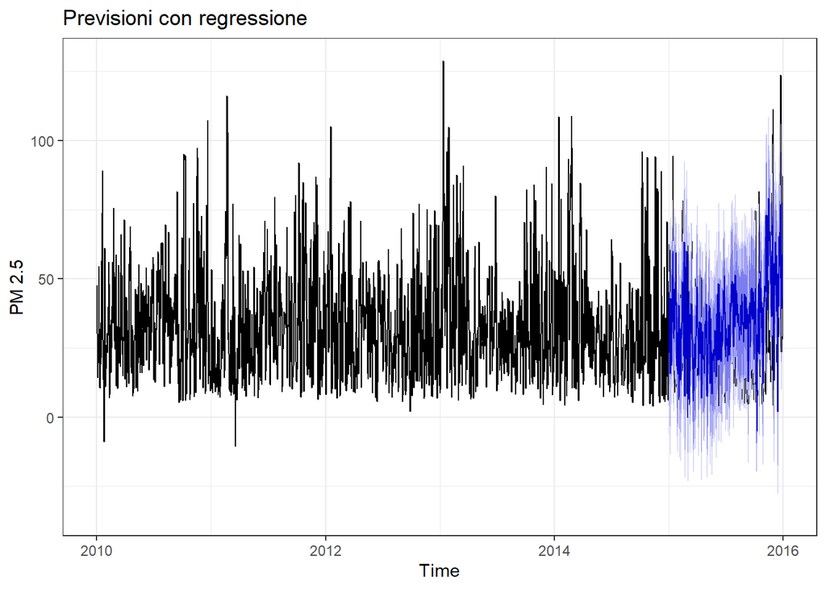

```r
# Previsioni con regressione
train_set2 <- window(tData1, start=2010,end=2015)
test_set2 <- window(tData1, start= 2015, end=2015.995)
fit1_p <- tslm(PM25 ~ dew_point + cum_windspeed + temperature + pressure + humidity + precipitation , data = train_set2)

test_set2 <- as.data.frame(test_set2)
fc1 <- forecast(fit1_p,test_set2)

autoplot(tData1[,"PM25"])+ autolayer(fc1) +ylab("PM 2.5")+ggtitle("Previsioni con regressione") + theme_bw()
```

## Decomposizione della serie storica

Considerate le **componenti principali** di una serie storica quali: trend, stagionalità e irregolarità, è possibile applicare la decomposizione delle sue componenti che può essere di tipo additivo o moltiplicativo. Il primo è utilizzato quando l’entità delle fluttuazione stagionali non cambia con il livello della serie, il secondo quando le fluttuazioni sono proporzionali al livello della serie.  
E’ possibile, tuttavia, ricondursi ad una decomposizione additiva tramite trasformazione di Box-Cox.

**Decomposizione additiva**: $y_t = S_t + T_t + R_t$

**Step**:

1. Stima della componente di trend-ciclica utilizzando la **media mobile**, definita come la media in un intervallo predefinito per ogni livello della serie, ciò permette di eliminare parte della casualità dei dati.
2. Calcolo della serie de-trendizzata: $y_t - \hat{T_t}$
3. Stima della componente stagionale, attraverso la media dei valori detrendizzati per quella stagione.
4. Calcolo della componente residua: $\hat{R_t}= y_t - \hat{S_t} - \hat{T_t}$

Utilizzando la funzione **decompose** è possibile ottenere tutte le **componenti stimate** utilizzando la decomposizione classica.

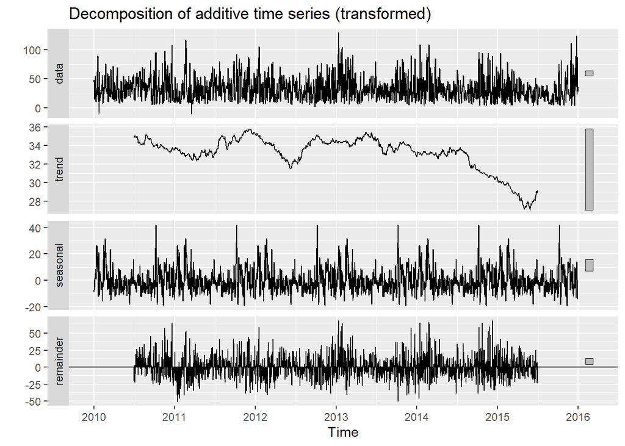

```r
# Decomposizione classica
additive <- decompose(tData1[,"PM25"],type = "additive")
autoplot(additive)+ ggtitle("Decomposition of additive time series (transformed)")
```

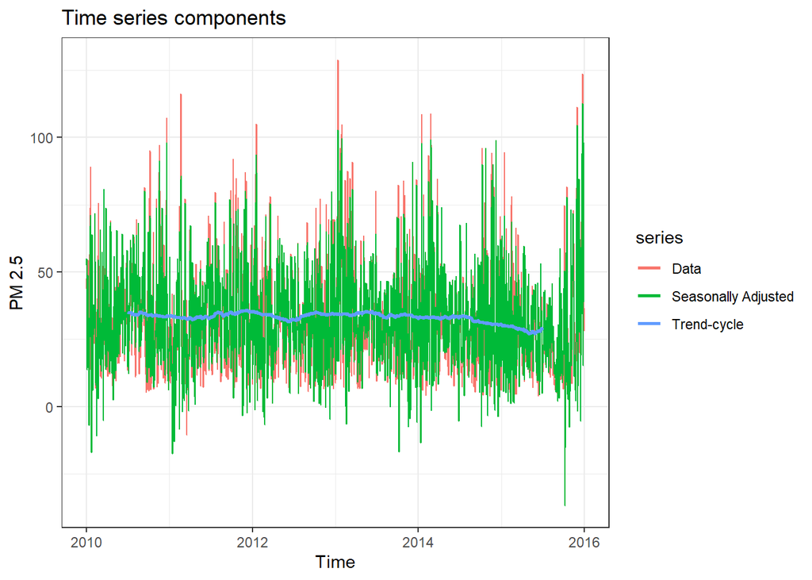

```r
#
autoplot(tData1[,"PM25"], series="Data") +
  autolayer(seasadj(additive), series="Seasonally Adjusted", size=0.5) + # yt - St
  autolayer(trendcycle(additive), series="Trend-cycle", size=1) + # Tt
  theme(legend.position="bottom") + ylab("PM 2.5") + theme_bw() + ggtitle("Time series components")
```

Altri tipi di decomposizione sono quella **X11** e **SEATS** (Seasonal Extraction in ARIMA Time Series) che permettono alla stagionalità di cambiare nel tempo diversamente da quella classica, e avere una componente trend/ciclica meno “smussata” per picchi e ribassi, inoltre perfomano meglio in caso di shock temporali, tuttavia non è applicabile per dati giornalieri come nel nostro caso.

Un altro tipo di decomposizione più sofisticata che permette di trattare anche dati giornalieri è quella **STL** (Seasonal and Trend decomposition using Loess).

Inoltre, con la funzione stl la componente stagionale non è considerata costante per ogni periodo e permette di catturare l’effetto variabile. Questo tipo di decomposizione tuttavia, consente solo quella additiva (risolvibile con la trasformazione di Box-Cox).

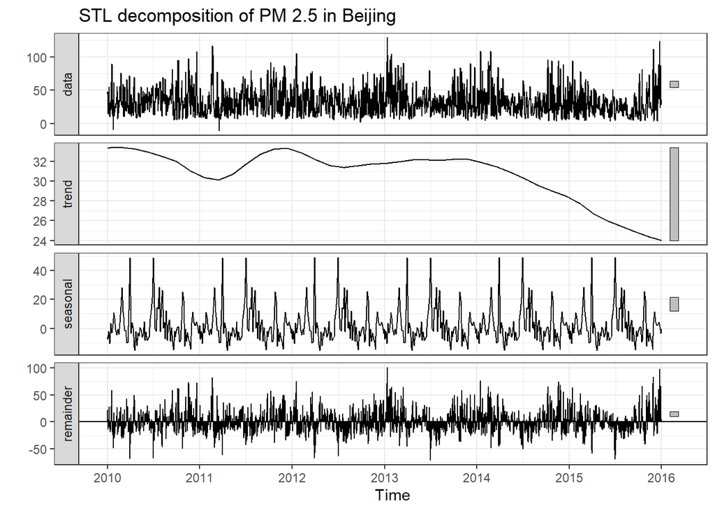

```r
stl.fit <- stl(tData1[,"PM25"],s.window="periodic", robust=TRUE)

autoplot(stl.fit) +
  ggtitle("STL decomposition of PM 2.5 in Beijing") + theme_bw()
```

### Previsioni con decomposizione STL

```r
# Previsioni
fc1 <- stlf(train_set2[,"PM25"], s.window="periodic", robust=TRUE, method="naive",h=365)
fc2 <- stlf(train_set2[,"PM25"], s.window="periodic", robust=TRUE, method="rwdrift",h=365)

acr_nv <- accuracy(fc1,test_set2[,"PM25"])[2,ind]
acr_df <- accuracy(fc2,test_set2[,"PM25"])[2,ind]
rbind(acr_nv,acr_df)
```

```
##            RMSE      MAE     MAPE     MASE
## acr_nv 25.85995 19.02767 77.50222 1.353739
## acr_df 27.52806 20.09701 74.02821 1.429818
```

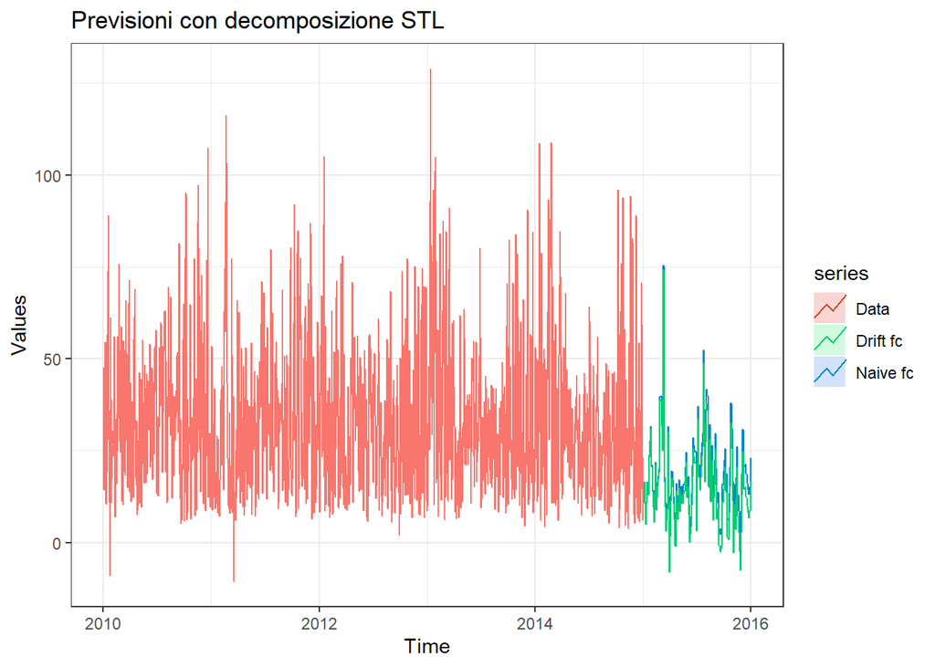

```r
autoplot(train_set2[,"PM25"], series="Data") + autolayer(fc1,PI=FALSE,series = "Naive fc")+
  ylab("Values") + ggtitle("Previsioni con decomposizione STL")+ autolayer(fc2,PI=FALSE,series = "Drift fc")+
  theme_bw()
```

## Modello ARIMA con stagionalità

Uno delle famiglie di modelli più ampiamente utilizzate per la previsione di serie storiche è quella **ARIMA** (Auto Regressive Integrated Moving Average), in particolare sono **auto regressivi** perchè si basano sui valori passati della variabile considerata, mentre la **media mobile** utilizza gli errori previsti passati, ed infine il modello Arima unisce questi due aspetti “integrandoli” tra loro, in particolare utilizzando la differenziazione per rendere la serie storica stazionaria.
$$ARIMA(p,d,q)$$
Il valore **p** indica la parte auto-regressiva, **d**, il livello di differenziazione e **q**, il livello della media mobile.

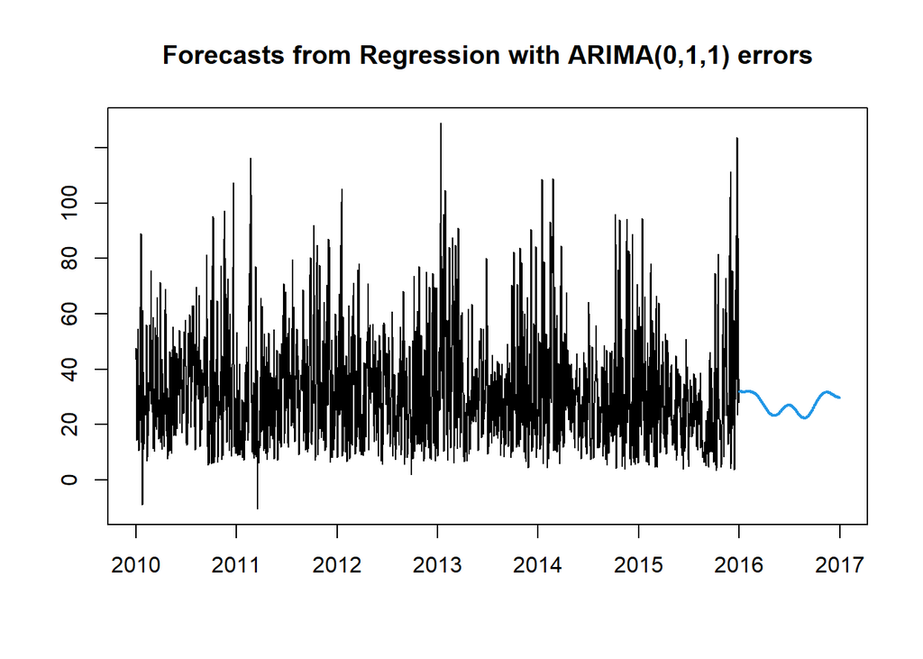

```r
fit_ar1 <- auto.arima(tData1[,"PM25"], xreg=fourier(tData1[,"PM25"],4),seasonal = FALSE)

newreg <- fourier(tData1[,"PM25"],4,h=365)
fc_ar1 <- forecast(fit_ar1,xreg=newreg)
plot(fc_ar1,PI=FALSE)
```

## Conclusione

L’obiettivo di questo progetto non è stato quello di trovare il modello con le migliori performance previsive ma mostrare e utilizzare buona parte degli strumenti utili per l’analisi di serie storiche. In modo speciale, la qualità dei dati reali ha un impatto particolare per produrre una buona indagine che rispecchia a pieno il **fenomeno reale** che si vuole analizzare.  
Soprattutto per i nostri dati si è visto che probabilmente un modello efficace richiede una complessità maggiore per far fronte alla **multi-stagionalità** che in caso di dati giornalieri molto lunghi può richiedere sia quella settimanale che quella giornaliera.